# ds202_hw5

Grant Ruedy

4/6/2019

```r
if (file.exists("alcohol.rds")) {
  data <- readRDS("alcohol.rds")
} else {
  url <- "https://xdaiisu.github.io/ds202materials/data/ames.csv"
  data <- readr::read_csv(url)
  saveRDS(data, file="alcohol.rds")
}
```

```r
library(tidyverse)
library(lubridate)
library(dplyr)


data1 <-data %>% separate(`Store Location`, c("address1", "address2", "coords"), sep = "\n") %>%
  mutate(coords = gsub("[()]", "", coords)) %>%
  separate(coords, c("latitude", "longitude"), sep = ",")
data1[10:11] #extracting latitude and longitude
```

```
## # A tibble: 382,033 x 2
##    latitude  longitude
##    <chr>     <chr>
##  1 42.022854 " -93.618911"
##  2 42.022854 " -93.618911"
##  3 42.022854 " -93.618911"
##  4 42.022854 " -93.618911"
##  5 42.001123 " -93.613648"
##  6 42.001123 " -93.613648"
##  7 42.001123 " -93.613648"
##  8 42.001123 " -93.613648"
##  9 42.001123 " -93.613648"
## 10 42.001123 " -93.613648"
## # ... with 382,023 more rows
```

```r
str(data1)
```

```
## Classes 'tbl_df', 'tbl' and 'data.frame':    382033 obs. of  27 variables:
##  $ Invoice/Item Number  : chr  "INV-15386000001" "INV-15386000002" "INV-15386200001" "INV-15386600001" ...
##  $ Date                 : chr  "10/31/2018" "10/31/2018" "10/31/2018" "10/31/2018" ...
##  $ Store Number         : num  4129 4129 4129 4129 3524 ...
##  $ Store Name           : chr  "Cyclone Liquors" "Cyclone Liquors" "Cyclone Liquors" "Cyclone Liquors" ...
##  $ Address              : chr  "626 Lincoln Way" "626 Lincoln Way" "626 Lincoln Way" "626 Lincoln Way" ...
##  $ City                 : chr  "Ames" "Ames" "Ames" "Ames" ...
##  $ Zip Code             : num  50010 50010 50010 50010 50010 ...
##  $ address1             : chr  "626 Lincoln Way" "626 Lincoln Way" "626 Lincoln Way" "626 Lincoln Way" ...
##  $ address2             : chr  "Ames 50010" "Ames 50010" "Ames 50010" "Ames 50010" ...
##  $ latitude             : chr  "42.022854" "42.022854" "42.022854" "42.022854" ...
##  $ longitude            : chr  " -93.618911" " -93.618911" " -93.618911" " -93.618911" ...
##  $ County Number        : num  85 85 85 85 85 85 85 85 85 85 ...
##  $ County               : chr  "STORY" "STORY" "STORY" "STORY" ...
##  $ Category             : num  1031100 1062400 1022200 1022200 1901200 ...
##  $ Category Name        : chr  "American Vodkas" "Spiced Rum" "100% Agave Tequila" "100% Agave Tequila" ...
##  $ Vendor Number        : chr  "301" "260" "410" "260" ...
##  $ Vendor Name          : chr  "FIFTH GENERATION INC" "DIAGEO AMERICAS" "Patron Spirits Company" "DIAGEO AMERICAS" ...
##  $ Item Number          : num  38177 43337 88296 87485 936859 ...
##  $ Item Description     : chr  "Titos Handmade Vodka" "Captain Morgan Spiced Rum" "Patron Tequila Silver" "Don Julio Blanco Tequila" ...
##  $ Pack                 : num  12 12 12 6 6 6 12 12 12 6 ...
##  $ Bottle Volume (ml)   : num  1000 1000 750 750 1750 ...
##  $ State Bottle Cost    : num  12.67 11.75 27.5 28.99 8.51 ...
##  $ State Bottle Retail  : num  19 17.6 41.2 43.5 12.8 ...
##  $ Bottles Sold         : num  24 12 12 6 360 6 12 288 24 18 ...
##  $ Sale (Dollars)       : num  456 212 495 261 4597 ...
##  $ Volume Sold (Liters) : num  24 12 9 4.5 630 6.75 12 288 18 31.5 ...
##  $ Volume Sold (Gallons): num  6.34 3.17 2.37 1.18 166.42 ...
```

```r
data1$Date <- mdy(data1$Date)
data1$`Vendor Number` <- as.numeric(data1$`Vendor Number`)
data1$latitude <- as.numeric(data1$latitude)
data1$longitude <- as.numeric(data1$longitude)
data1$County <- factor(data1$County)
data1$`Category Name` <- factor(data1$`Category Name`)


data4 <- data %>% separate(Date, c("month", "day", "year"), sep = "/")

data4[2:4] #extracting month , day, year
```

```
## # A tibble: 382,033 x 3
##    month day   year
##    <chr> <chr> <chr>
##  1 10    31    2018
##  2 10    31    2018
##  3 10    31    2018
##  4 10    31    2018
##  5 10    31    2018
##  6 10    31    2018
##  7 10    31    2018
##  8 10    31    2018
##  9 10    31    2018
## 10 10    31    2018
## # ... with 382,023 more rows
```

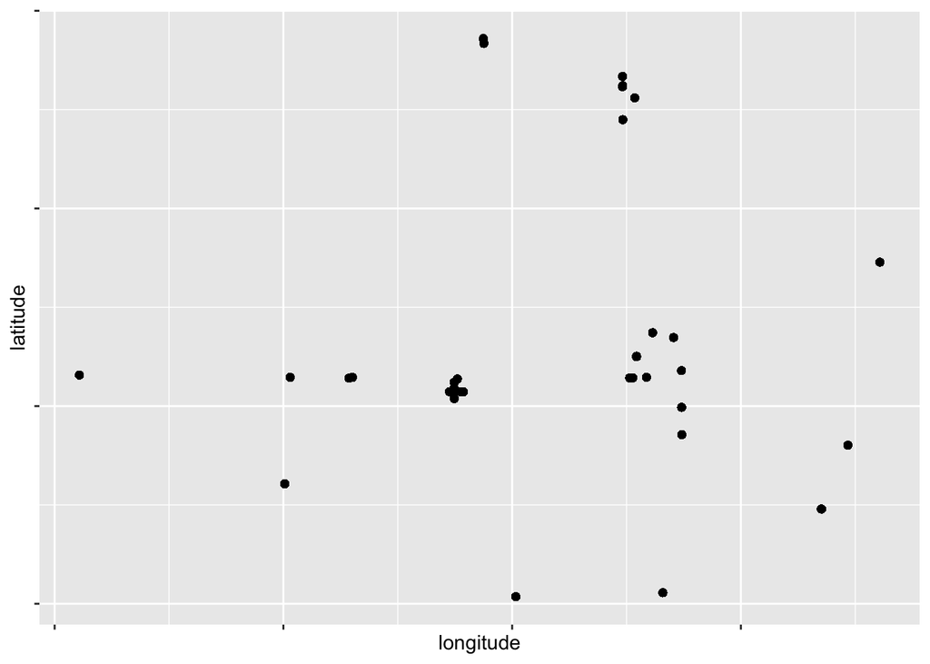

```r
#scatterplot of lat and long of store locations.
ggplot(data1, aes(x=longitude, y=latitude)) + geom_point(na.rm = T) +
  theme(axis.text.x = element_blank(),axis.text.y = element_blank())
```

```
## $`1`
```

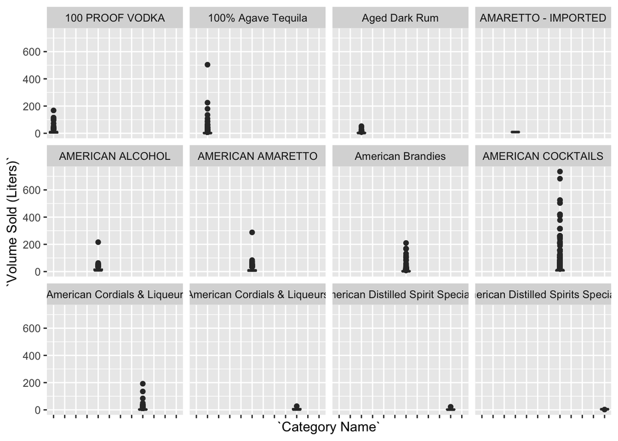

```
##
## $`2`
```

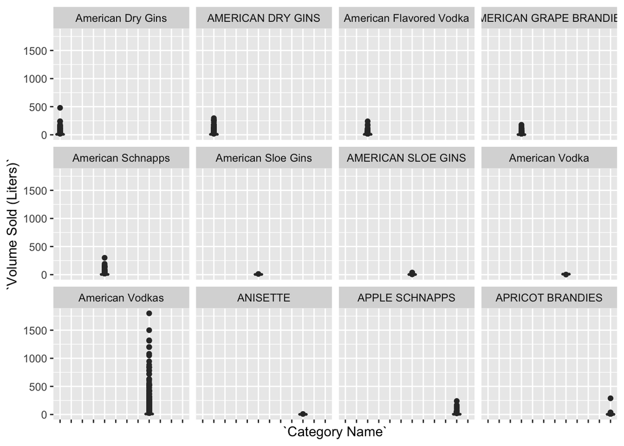

```
##
## $`3`
```

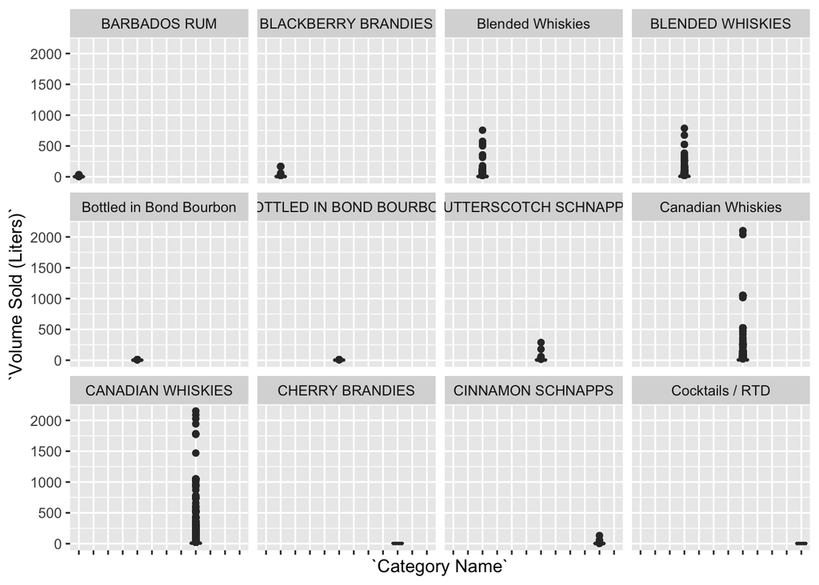

```
##
## $`4`
```

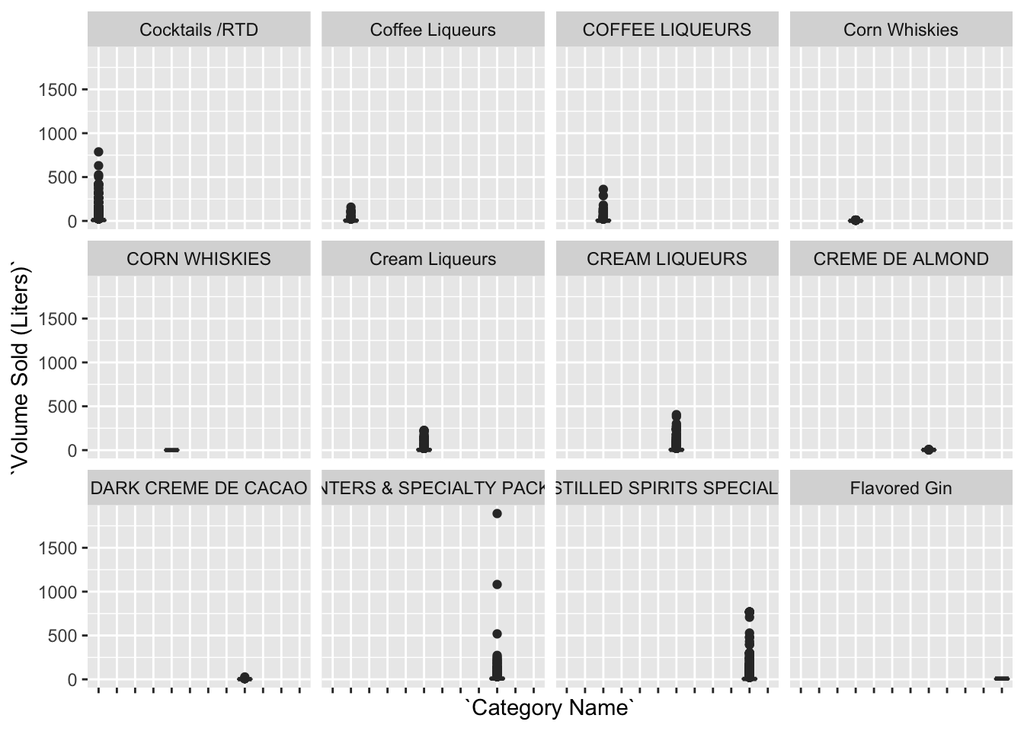

```
##
## $`5`
```

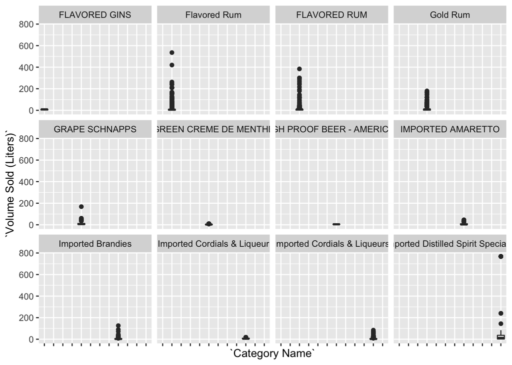

```
##
## $`6`
```

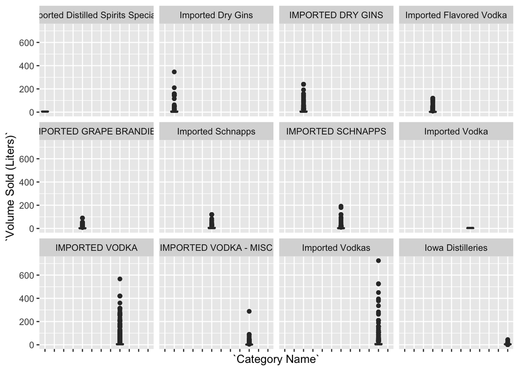

```
##
## $`7`
```

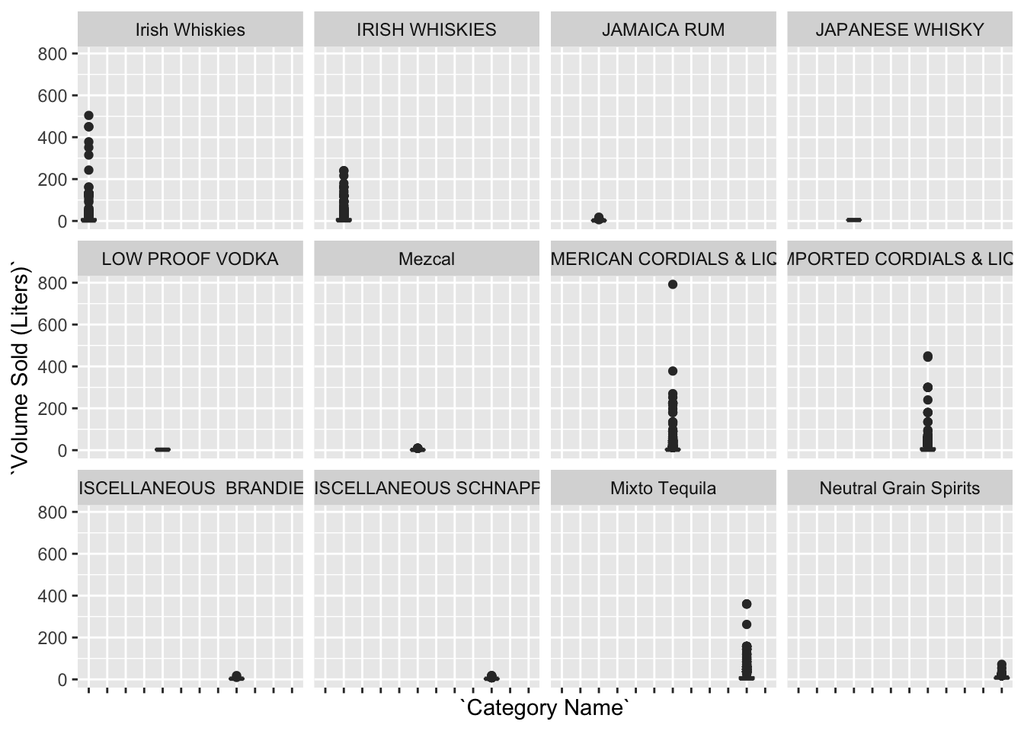

```
##
## $`8`
```

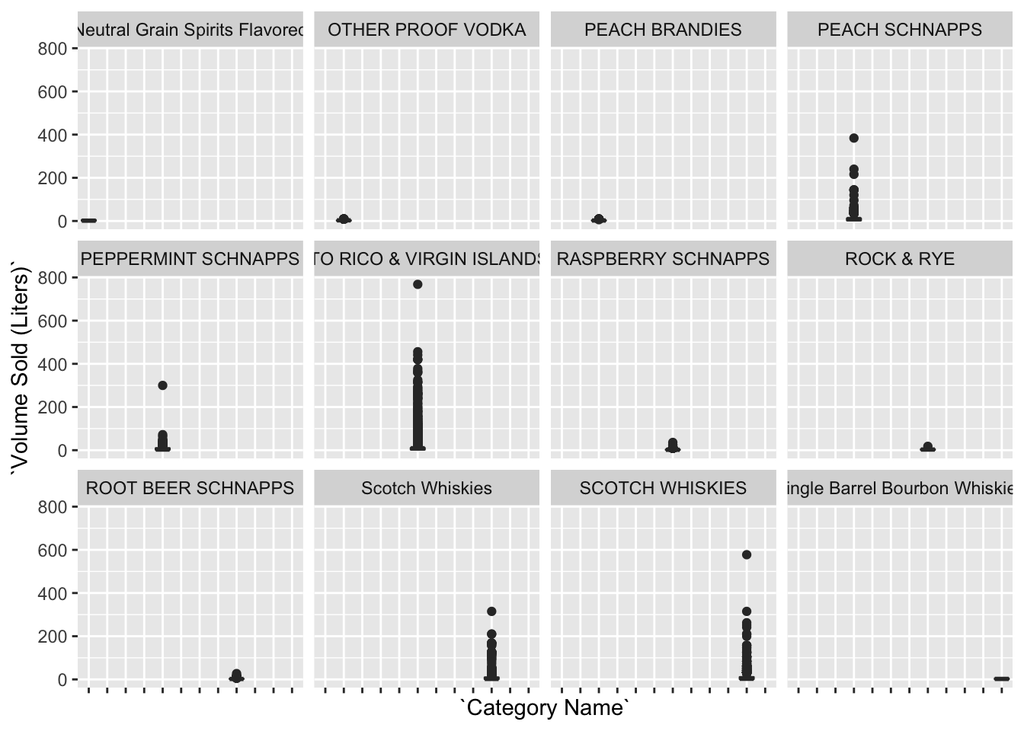

```
##
## $`9`
```

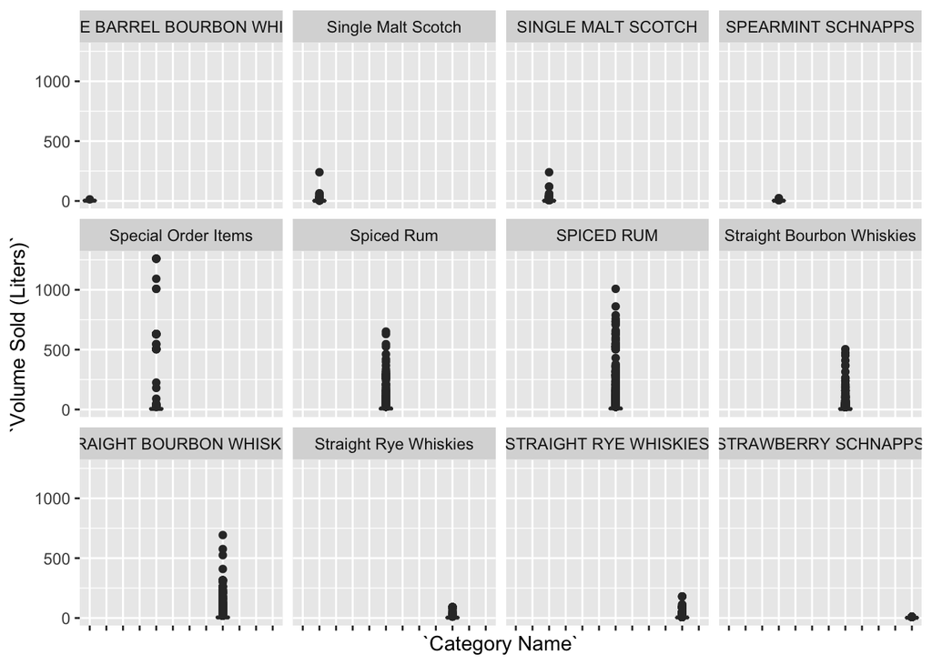

```
##
## $`10`
```

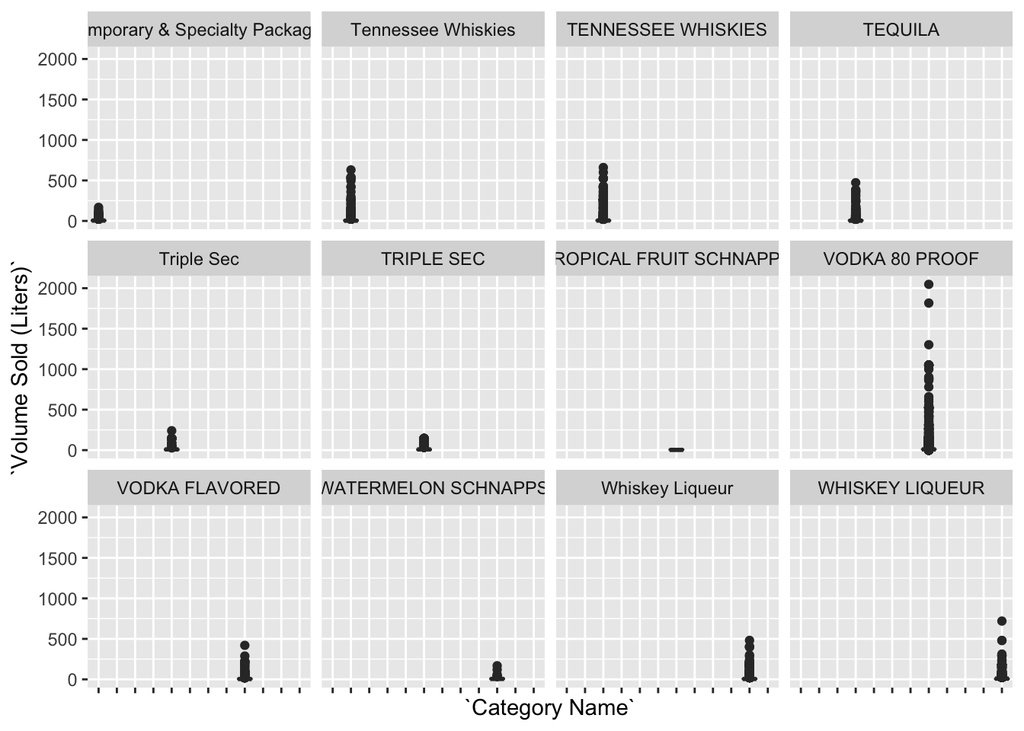

```
##
## $`11`
```

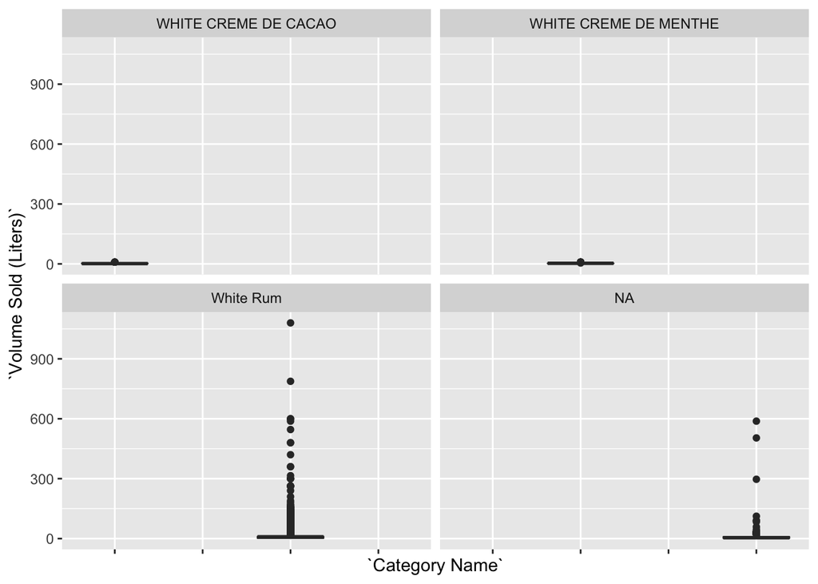

```r
#visual breakdown of the liquor category
library(tidyverse)
myplots3 <-
  data1 %>%
  split(ceiling(group_indices(.,`Category Name`)/12)) %>%
  map(~ggplot(.,aes(x=`Category Name`,y=`Volume Sold (Liters)`))+geom_boxplot()+facet_wrap(~`Category Name`) +
        theme(axis.text.x = element_blank()))

myplots3
```

```r
#subsetting to liquor sales in Ames in 2018.
data2 <- data1[year(data1$Date)=='2018',]


#Summarize number of sales, volume of liquor sold and amount of money spent
data2 %>% group_by(yday(Date)) %>% summarize(number.of.sales=sum(`Bottles Sold`),
                                            volume.of.liquor=sum(`Volume Sold (Liters)`),
                                            money.spent=sum(`Sale (Dollars)`))
```

```
## # A tibble: 146 x 4
##    `yday(Date)` number.of.sales volume.of.liquor money.spent
##           <dbl>           <dbl>            <dbl>       <dbl>
##  1            3            7133          6596.      104862.
##  2            5            2632          1966.       31048.
##  3           10           10413         10250.      141905.
##  4           12            1510          1347.       17881.
##  5           17           10449         10196.      159217.
##  6           18               1             0.75        11.2
##  7           19            1241          1148.       15664.
##  8           22               3             2.25         0
##  9           24            8625          8273.      124823.
## 10           25               1             0.75        20.8
## # ... with 136 more rows
```

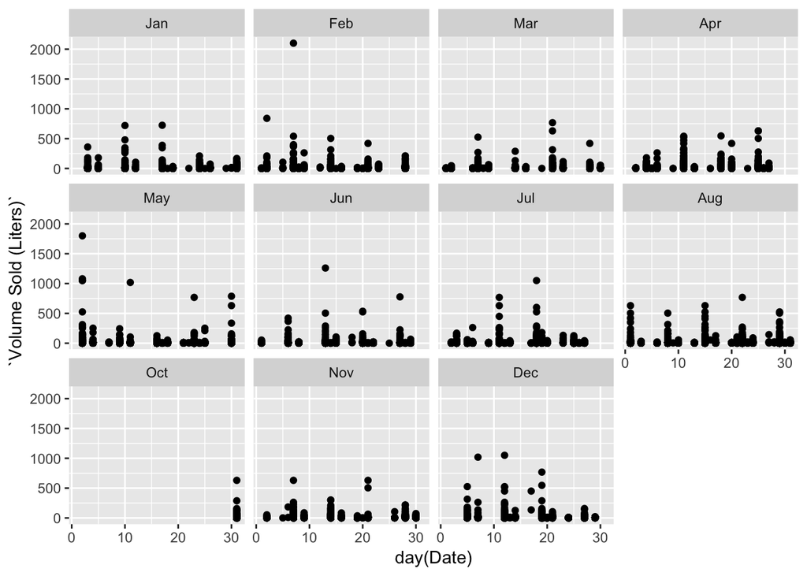

```r
#plot of volume sold by day
ggplot(data2, aes(x=day(Date), y=`Volume Sold (Liters)`)) + geom_point() + facet_wrap(~month(Date, label=T))
```

Based off of the plot showing volume of alcohol sold by day, there seems to be a pattern of most alcohol is sold in the beginning months of the year. Especially in May, this trend can be seen as the number of points above 1000 liters sold is the most of any month. Another interesting pattern is the extreme observation in February. This could have been because of the SuperBowl, one of the largest sporting events in the world. One final pattern worth noting is how for almost every month, the sales seem to spike every week or so. This makes sense as more people drink and buy alcohol on the weekend.

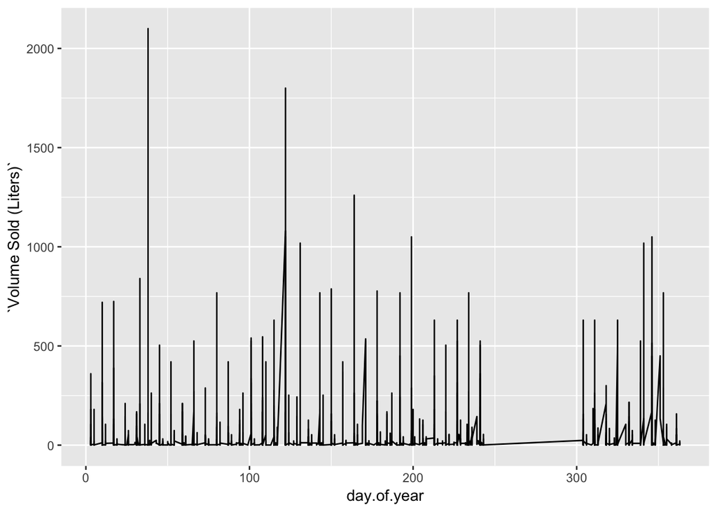

```r
#Dates for ISU football home games in 2018
game1 <- mdy('9-15-2018')
game2 <- mdy('9-22-2018')
game3 <- mdy('10-13-2018')
game4 <- mdy('10-27-2018')
game5 <- mdy('11-10-2018')
game6 <- mdy('11-24-2018')
game7 <- mdy('12-1-2018')

data3 <-data2 %>%
  mutate(day.of.year =yday(Date))
ggplot(data3, aes(x=day.of.year, y=`Volume Sold (Liters)`)) +geom_line()
```